# Classification of media and countries

Sirius Project - Working Paper 001

Author

Claude Grasland

Published

2026-02-24

## Research question

Which vision of an unknown world could be produced by an external observer starting just from an interaction matrix ? Which type of geometries could be used by this observer ? And which criteria could help him to distinguish between these geometries in order to choose the most accurate - if it does make sense to choose one “best” ?

# A. Experimental protocol

## The Rosette stone

We consider an observer from Sirius trying to understand the organisation of our world on a time period comprised between June 2013 and June 2020. This observer (that we will call “it” as we ignore everything from he/she) has absolutely no preconceived idea on the geometry of our world, including the fact that we are located on a planet taking the form of a sphere. The only information at its disposal is a large set of short messages corresponding to the title and description of news published by newspapers located in different places of the world and published in different languages. As it ignores everything from ou grammar, the information received should look for him like this :

|  | source | time | message |
| --- | --- | --- | --- |
| 1 | media_1 | 2014-03-01 | jCAA0s us5 653G 36Aw tG vwABst030H05y m29s05w: Wv0B690s3 . jCAA0s Az6C3v zw37 m29s05w ywB 0BA 5wE y6Dw954w5B C7 s5v 9C5505y 05ABwsv 6x 5C9A05y s y9Cvyw 6Dw9 Bz |
| 2 | media_1 | 2014-03-01 | m29s05w'A n02B69 qs5C26DGuz 4s2wA 4wv0s vwtCB 05 jCAA0s . ax 6CABwv m29s050s5 79wA0vw5B n02B69 qs5C26DGuz E9s77wv z04Aw3x 05 Bzw x3sy, 0B E6C3v tw s5 C5u64x69 |
| 3 | media_1 | 2014-03-01 | Us5svs'A W902 YCsG E05A o693v UC7 v6E5z033 05 f69EsG . VCx6C9-ds7605Bw A0ABw9A, 4ws5Ez03w, Azs9w o693v UC7 46yC3A 76v0C4 05 bs7s5. |
| 4 | media_1 | 2014-03-01 | ozG m29s05w 0A 56B Bzw U63v os9 9wD0A0Bwv: TC94s5 . lzw 9zwB690u 6Dw9 m29s05w &amp;#QKJK; 70BB05y Bzw owAB sys05AB jCAA0s &amp;#QKJK; 0A s vs5yw96CA KIBz-uw5BC9 |
| 5 | media_1 | 2014-03-01 | mkS uC90BG U6C5u03 B6 z63v u36Awv v669 4wwB05y 65 m29s05w . m29s05w zsA s39wsvG suuCAwv jCAA0s 6x &amp;#QKKI;s 4030Bs9G 05DsA065 s5v 6uuC7sB065&amp;#QKKJ; 6x AB9sBwy0u |
| 6 | media_1 | 2014-03-02 | lzw owAB E033 &amp;#QKJO;y6 B6 Bzw z03B&amp;#QKJP; B6 0A63sBw jCAA0s 6Dw9 m29s05w: b6z5 cw99G . owABw95 76Ew9A s9w 79w7s9wv &amp;#QKKI;B6 y6 B6 Bzw z03B&amp;#QKKJ; B6 0A63sBw jCAA0s x69 0BA 4030Bs9G 0… |
| 7 | media_1 | 2014-03-02 | b6z5 Ts09v AsGA Us5svs u65A0vw905y s33 76AA0t3w As5uB065A sys05AB jCAA0s 6Dw9 m29s05w . Us5svs zsA s39wsvG 9C3wv 6CB 4030Bs9G 05Bw9Dw5B065 6Dw9 jCAA0s'A 05D63Dw4w5B 05 m29s05w. |
| 8 | media_1 | 2014-03-03 | Y36ts3 AB6u2 4s92wBA BC4t3w sA Bw5A065A 90Aw 05 m29s05w . Y36ts3 AB6u2A BC4t3wv e65vsG sA Bw5A065 6Dw9 jCAA0s&amp;#QKJP;A 4030Bs9G svDs5uw 05B6 m29s05w s5v 76AA0t |
| 9 | media_1 | 2014-03-03 | Us5sv0s5 46vw3 z63vA 76AA0t3w A63CB065 B6 Bzw u90A0A 05 U904ws: YEG5 . e6AB 6x Bzw 9wA765AwA B6 jCAA0s&amp;#QKJP;A tC33G05y 05 m29s05w s5v U904ws 56E tw05y ACyywABwv Aww4 A033 |
| 10 | media_1 | 2014-03-03 | m29s05w u65x30uB Bz9wsBw5A w5w9yG, 9wBs03, xsAB x66v, A7662A 05Bw95sB065s3 05DwAB69A . Wu65640u 047suB 6x jCAA0s&amp;#QKJP;A 4030Bs9G 05Bw9Dw5B065 xw3B tG u69769sBw y0s5BA ACuz sA euV65s3v&amp;#Q |

[output cut: 83 more lines]

```
[1] "aA9sw3"
```

Admitting that our Sirius observed has understood that blank spaces are separators of tokens, it will probably notice quickly that in the source called **USf_B6ABs9* some tokens are frequently replicated in the message like *“jCAAs, kG90s”, “m50Bwv kBsBwA”, “aA9sw3”*…

Looking at another source our observer will probably be disappointed to discover that the language is clearly different. But it will probably noticed also some recurrence of tokens and some similarities between for example the tokens *kG90s* and *kC90sz* or between *jCAAs* and *jCA0s*. And it will certainly observe that this tokens are often associated, approximatively at the same time period, the same week or the same day.

|  | source | time | message |
| --- | --- | --- | --- |
| 1 | media_2 | 2014-03-01 | lw5Bs9s aA9sw3 lw4ts2 esB0 fw5w2 Ys5yyCs5 ew5Bs3 . jWhmTdacS.Ug.aV, YSrS -- lw5Bs9s aA9sw3 4w5w4ts2 vs5 4w4tC5Cz Aw69s5y Es50Bs hs3wAB05s v0 bs3C9 YsHs |
| 2 | media_2 | 2014-03-01 | hC3Czs5 j0tC g9s5y Tw9C51C2 jsAs v0 V65wBA2 m29s05s . jWhmTdacS.Ug.aV, VgfWlkc -- dwt0z vs90 JI.III 69s5y 4w5y0ts92s5 tw5vw9s jCA0s 7svs kstBC. ew9w2s 4w3 |
| 3 | media_2 | 2014-03-01 | qs5C26DGuz ds90 2w jCA0s, m29s05s e05Bs V0w2AB9sv0A0 . jWhmTdacS.Ug.aV,bScSjlS--cw7s3s cw1s2Ass5 m29s05s 4w405Bs jCA0s C5BC2 4w5yw2AB9sv0A0 h9wA0vw5 m29s05 |
| 4 | media_2 | 2014-03-01 | m29s05s e05Bs jCA0s Tw9v0s36y lw5Bs5y c904ws . f694s3 I xs3Aw xs3Aw xs3Aw Wf-mk p-fgfW p-fgfW ... |
| 5 | media_2 | 2014-03-01 | S9st ksCv0 c90B02 jCA0s VC2C5y hw4w905Bsz kC90sz . jWhmTdacS.Ug.aV, jaqSVZ -- S9st ksCv0 4w4ts3sA 2wus4s5 jCA0s sBsA 9w5us5s5Gs C5BC2 4w4sA62 9Cvs3-9Cv |
| 6 | media_2 | 2014-03-01 | SxAw3: cw4w9vw2ss5 cs40 ls2 dw5y2s7 ls57s cw4w9vw2ss5 hs3wAB05s . jWhmTdacS.Ug.aV, bScSjlS -- a5v65wA0s tw9As4s Sx902s kw3sBs5 tw2w91s As4s vs3s4 7w4ts5yC5s5 hs3wAB05 |
| 7 | media_2 | 2014-03-01 | VC2C5y hw4w905Bsz kC90sz, jCA0s V02wus4 ksCv0 . jWhmTdacS.Ug.aV, jaqSVZ -- S9st ksCv0 4w4ts3sA 2wus4s5 jCA0s sBsA 9w5us5s5Gs C5BC2 4w4sA62 9Cvs3-9Cv |
| 8 | media_2 | 2014-03-02 | hCB05: hw4w905Bsz Ts9C m29s05s ew5vC2C5y S2A0 cw1szsBs5 . jWhmTdacS.Ug.aV, egkcgo -- jCA0s 4w403020 zs2 C5BC2 4w305vC5y0 2w7w5B05ys5-2w7w5B05ys55Gs vs5 7w5vCv |
| 9 | media_2 | 2014-03-02 | m29s05s Tw9A0s7 Zsvs70 jCA0s vw5ys5 cwBw9tsBsAs5 . jWhmTdacS.Ug.aV, caWn -- hw4w905Bsz ts9C m29s05s 4w5Gw9C2s5 A0vs5y vs9C9sB VwEs5 cws4s5s5 fsA065s3 7 |
| 10 | media_2 | 2014-03-02 | U05s kw9C2s5 V0s36y m5BC2 kw3wAs02s5 c90A0A m29s05s . jWhmTdacS.Ug.aV, TWabafY -- cw4w5Bw90s5 dCs9 fwyw90 U05s 7svs Szsv (K/L) 4w5ysBs2s5, As5ysB 2zsEsB09 |

[output cut: 105 more lines]

But some sources will appear more difficult, for example because they use a different alphabet or are written from left to right, instead of right to left… Our observer from Sirius will have many difficulties to solve the problem of translation. But imagine the discovery of a Rosette stone where it will recognise many of the tokens previously mentionned. This Rosette Stone could take the form of an ISO3 code of states associated to all the possible translations of the names of countries in different languages. Something like that :

| OSI3 | lang1 | lang2 | lang3 | lang4 |
| --- | --- | --- | --- | --- |
| mkS | m50Bwv kBsBwA | WBsBA-m50A | +BCEEKAQQ | +MAx8c1b9MA |
| kqj | kG90s | kG90w | -+BCEEOARABDgET | 0-+MAwwtzDqMKIwD |
| jmk | jCAA0s | jCAA0w | w-+BCAEPgRBBEEEOARP | Q-+MAww7TC3MKIwD |
| akj | aA9sw3 | aA9së3 | -+BBgENwRABDAEOAQ7BE | Q-+MAwwpDC5MOkwqDDrMA |

It is now possible to simplify our initial information and build a dataframe reduced to the three columns who, where, what.

|  | who | when | what |
| --- | --- | --- | --- |
| 1 | media_2 | 2016-01-01 | VEN |
| 2 | media_2 | 2016-01-01 | DEU |
| 3 | media_2 | 2016-01-01 | FRA |
| 4 | media_2 | 2016-01-01 | USA |
| 5 | media_2 | 2016-01-01 | VEN |
| 6 | media_2 | 2016-01-01 | VEN |
| 7 | media_2 | 2016-01-01 | DEU |
| 8 | media_2 | 2016-01-01 | PER COL |
| 9 | media_2 | 2016-01-01 | UKR |
| 10 | media_2 | 2016-01-01 | USA |

[output cut: 10 more lines]

## The host-guest matrix

A first way to analyze the item is to build what can be called an host-guest matrix where the media (who) plays the role of hots that invite information about foreign countries that plays the role of guests. In our small example of two media during one week, we can extract a matrix describing the respective number of guest-host relation in the two media.

|  | what | media_1 | media_2 | tot |
| --- | --- | --- | --- | --- |
| 1 | USA | 1390 | 1233 | 2623 |
| 2 | CHN | 729 | 291 | 1020 |
| 3 | GBR | 431 | 173 | 604 |
| 4 | NZL | 348 | 22 | 370 |
| 5 | FRA | 97 | 217 | 314 |
| 6 | RUS | 139 | 173 | 312 |
| 7 | JPN | 168 | 127 | 295 |
| 8 | SYR | 79 | 196 | 275 |
| 9 | ARG | 30 | 241 | 271 |
| 10 | VEN | 12 | 242 | 254 |

[output cut: 10 more lines]

```
  what media_1 media_2 tot          pi          pj        pos      size
1  VEN      12     242 254 0.002053037 0.040380444 -0.9032351 2.1216740
2  CUB       9      92 101 0.001539778 0.015351243 -0.8176809 0.8445510
3  COL      14     118 132 0.002395210 0.019689638 -0.7830902 1.1042424
4  ARG      30     241 271 0.005132592 0.040213583 -0.7736262 2.2673087
5  CHL       6      47  53 0.001026518 0.007842483 -0.7685154 0.4434501
6  CHE       7      53  60 0.001197605 0.008843651 -0.7614631 0.5020628
```

```
   what media_1 media_2 tot          pi          pj       pos      size
55  PAN      31       9  40 0.005303678 0.001501752 0.5586607 0.3402715
56  MYS      31       7  38 0.005303678 0.001168029 0.6390352 0.3235854
57  THA      73      16  89 0.012489307 0.002669781 0.6477649 0.7579544
58  JOR      75      12  87 0.012831480 0.002002336 0.7300309 0.7416908
59  ZAF     145      19 164 0.024807528 0.003170365 0.7733664 1.3988947
60  NZL     348      22 370 0.059538067 0.003670949 0.8838473 3.1604508
```

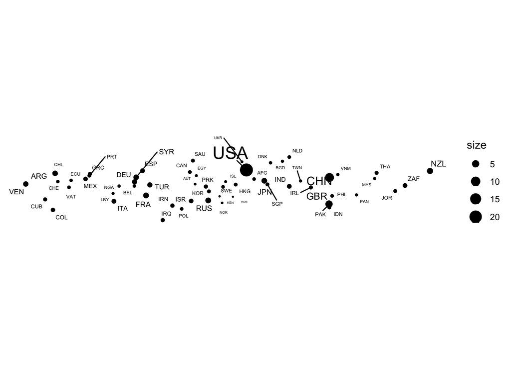

## Unfolding approach

Suppose now that we have k observers reporting on n states. We are typically in a situation of unfolding method. Let’s try with a simple example :

```
 [1] "ARG_nacion" "AUS_sydmor" "BRA_oglobo" "CAN_tostar" "CHN_mopost"
 [6] "DEU_frankf" "DZA_alnaha" "EGY_alwafd" "ESP_abc"    "FRA_figaro"
[11] "FRA_lmonde" "GBR_indept" "IDN_republ" "IND_tindia" "IRN_hamsha"
[16] "ISR_jerpos" "ITA_repubb" "JPN_asahis" "KEN_standa" "MEX_inform"
[21] "NGA_vangua" "PAK_thenew" "SGP_today"  "TUR_sabah"  "USA_nytime"
[26] "ZAF_times"
```

```
[1] 19 31
```

```
       ARG  CHN  CUB   DZA  EGY  GBR  GRC  HTI  IND  IRN  ISR  ITA  KEN  KOR
m_AUS 1.60 0.57 3.17 10.63 2.01 0.62 1.70 3.00 0.94 1.59 1.22 1.83 1.65 1.66
m_BRA 0.28 1.30 0.40  1.94 1.48 1.86 0.87 0.72 2.28 0.98 0.99 0.81 1.87 1.81
m_CAN 2.44 1.09 0.74  3.60 1.15 0.92 1.77 0.58 1.17 1.12 1.32 1.50 1.01 1.23
m_CHN 2.50   NA 2.66  8.28 2.49 0.68 3.21 1.72 0.69 1.91 2.89 2.32 1.82 0.41
m_DEU 1.44 0.98 1.47  0.94 1.40 1.35 0.34 2.07 1.90 0.85 0.97 0.52 1.43 1.32
m_DZA 1.02 3.21 0.99    NA 0.36 1.89 0.99 3.05 1.47 1.09 1.00 1.24 0.87 3.29
m_ESP 0.42 1.37 0.32  1.01 1.05 0.86 0.50 0.86 1.98 1.19 1.23 0.52 1.09 2.29
m_FRA 0.84 1.51 0.95  0.14 0.68 1.51 0.44 0.49 1.48 0.87 0.75 0.55 0.59 1.99
m_GBR 1.45 1.23 1.55  2.09 1.40   NA 1.13 1.20 1.10 1.04 0.83 0.96 0.94 1.49
m_IDN 1.43 1.21 3.15  1.72 0.72 0.86 3.28 0.52 1.39 0.88 0.47 0.72 2.19 1.25
m_IND 2.78 0.62 2.36  5.63 1.67 0.70 2.94 2.23   NA 1.01 1.78 2.04 1.80 1.46
m_IRN 2.18 1.28 2.33  0.99 0.88 2.61 1.83 2.46 1.33   NA 0.92 0.93 2.76 1.35
m_JPN 3.05 0.46 1.19  3.18 1.56 3.99 1.35 1.44 1.69 1.05 1.50 2.11 1.72 0.18
m_MEX 0.35 1.81 0.31  2.18 1.29 1.95 1.37 0.36 1.69 1.43 1.31 0.89 1.10 1.97
m_NGA 0.64 1.17 3.17  0.22 0.55 0.48 3.83 2.99 1.17 1.25 1.38 1.07 0.25 2.08
m_PAK 1.74 0.71 2.97  1.57 1.96 0.72 1.63 4.12 0.22 0.76 1.96 1.61 1.44 1.09
m_TUR 2.25 2.15 2.53  0.88 0.67 1.92 0.45 4.89 2.17 0.62 0.52 0.90 2.51 2.10
m_USA 2.00 0.73 0.87  2.63 1.27 0.89 1.00 0.53 0.93 0.81 0.98 1.36 1.11 0.91
m_ZAF 1.03 1.24 1.32  0.70 0.54 0.54 1.39 1.35 0.78 1.04 1.24 1.22 0.19 1.28
       LBY  MYS  PAK  PER  PHL  POL  PRK  PSE  RUS  SAU  SYR  TUR  UKR  USA
m_AUS 3.21 0.68 1.18 1.93 0.97 1.48 1.01 2.26 1.26 2.07 1.52 2.16 1.12 0.83
m_BRA 1.75 3.06 3.70 0.34 2.33 0.92 1.21 0.96 1.07 1.48 1.17 1.46 1.16 0.87
m_CAN 2.00 1.70 1.50 1.63 0.86 0.78 1.06 1.82 1.05 1.78 1.24 1.34 0.83 0.71
m_CHN 2.97 0.38 1.11 3.28 0.25 1.90 0.53 4.19 1.50 2.52 2.38 2.77 1.61 0.78
m_DEU 1.55 2.31 2.70 1.51 1.84 0.33 0.89 3.85 0.62 1.14 0.89 0.49 0.43 1.35
m_DZA 0.15 3.01 1.59 0.83 2.48 4.72 2.86 0.28 1.02 0.28 0.63 0.52 1.62 1.47
m_ESP 1.04 2.29 4.27 0.36 1.66 0.76 1.38 1.50 1.00 1.48 1.02 1.11 0.83 1.09
m_FRA 0.46 3.33 1.66 1.07 1.21 0.55 1.38 0.88 0.94 0.88 0.57 0.63 0.80 1.49
m_GBR 1.39 1.06 1.18 1.44 1.36 0.70 0.88 1.04 0.85 0.76 0.83 1.11 0.71 0.94
m_IDN 1.60 0.28 1.64 1.87 0.58 2.18 1.97 0.32 1.23 0.47 1.12 0.75 1.68 1.36
m_IND 2.01 0.93 0.15 3.54 1.51 1.66 1.36 2.54 1.73 1.41 1.76 2.19 1.60 0.96
m_IRN 1.52 1.34 0.86 1.46 2.33 0.93 1.68 0.77 0.69 1.77 0.70 0.48 1.40 0.91
m_JPN 2.72 1.02 2.57 1.58 0.87 2.75 0.22 1.57 0.87   NA 1.23 1.07 0.90 2.68
m_MEX 1.97 2.05 3.04 0.23 1.08 1.48 1.34 1.54 1.04 2.73 0.97 1.57 0.99 0.76
m_NGA 0.46 1.23 2.01 2.70 1.54 0.96 1.54 3.04 0.97 0.79 2.06 1.40 1.11 0.89
m_PAK 1.94 1.11   NA 2.69 1.35 1.10 2.40 1.90 1.47 0.83 1.94 1.11 2.46 1.06
m_TUR 1.09 2.01 1.89 2.47 2.68 1.33 2.06 0.60 0.71 0.73 0.48   NA 1.09 1.01
m_USA 1.27 2.07 1.46 1.70 0.97 0.92 0.87 1.58 1.09 1.37 1.17 1.29 0.76   NA
m_ZAF 0.55 0.95 1.01 2.72 0.85 1.50 1.65 1.45 1.22 1.96 1.07 1.66 0.87 0.98
       VEN  VNM  YEM
m_AUS 2.64 0.75 2.72
m_BRA 0.24 2.41 1.66
m_CAN 1.73 1.37 1.52
m_CHN 3.56 0.33 2.68
m_DEU 1.37 2.06 1.63
m_DZA 3.52   NA 0.28
m_ESP 0.24 1.77 1.91
m_FRA 0.80 1.95 0.56
m_GBR 2.57 1.57 0.95
m_IDN 2.24 0.64 0.94
m_IND 3.74 1.22 1.45
m_IRN 2.29 1.78 0.40
m_JPN 2.40 0.37 3.43
m_MEX 0.27 2.57 1.26
m_NGA 4.42 1.88 2.10
m_PAK 4.55 1.59 0.93
m_TUR 2.67 3.09 1.16
m_USA 1.36 0.64 0.96
m_ZAF 5.18 1.23 1.23
```

```
[1] 0.3656232
```

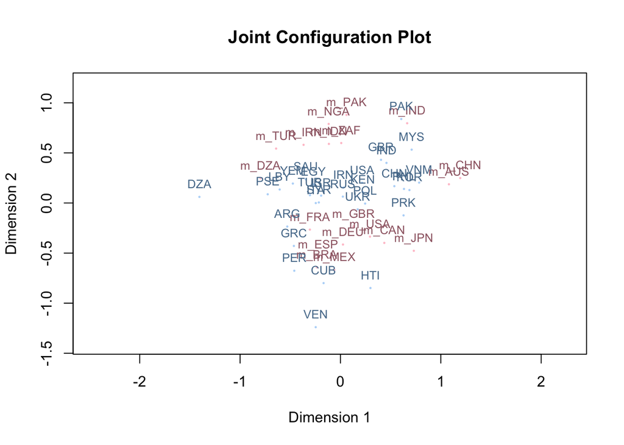